# Meta-regression

Audrey Beliveau, Justin Slater

2020-11-25

```r
library(BUGSnet)

data(afib)
dataprep <- data.prep(arm.data = afib,
                      varname.t = "treatment",
                      varname.s = "study")
```

## Feasibility Assessment

### Network Plot

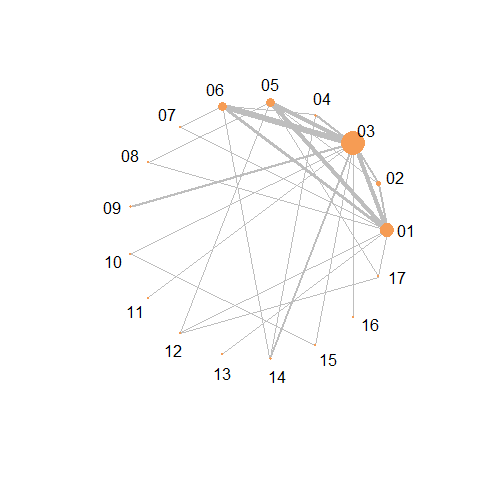

```r
 net.plot(dataprep, node.scale = 1,
          edge.scale=1,
          label.offset1 = 2)
```

### Generate Network Characteristics via `net.tab()`

```r
network.char <- net.tab(data = dataprep,
                        outcome = "events",
                        N = "sampleSize",
                        type.outcome = "binomial")
```

#### Network Characteristics

`network.char$network` generates characteristics about the network, such as connectedness, number of treatments in the network, and in the case of a binomial outcome, the number of events in the network.

| Characteristic | Value |
| --- | --- |
| Number of Interventions | 17 |
| Number of Studies | 26 |
| Total Number of Patients in Network | 27444 |
| Total Possible Pairwise Comparisons | 136 |
| Total Number of Pairwise Comparisons With Direct Data | 29 |
| Is the network connected? | TRUE |
| Number of Two-arm Studies | 17 |
| Number of Multi-Arms Studies | 9 |
| Total Number of Events in Network | 1249 |
| Number of Studies With No Zero Events | 25 |
| Number of Studies With At Least One Zero Event | 1 |
| Number of Studies with All Zero Events | 1 |

#### Intervention Characteristics

`network.char$intervention` generates outcome and sample size data broken down by treatment.

| treatment | n.studies | n.events | n.patients | min.outcome | max.outcome | av.outcome |
| --- | --- | --- | --- | --- | --- | --- |
| 01 | 11 | 223 | 2442 | 0.0329670 | 0.2666667 | 0.0913186 |
| 02 | 4 | 16 | 675 | 0.0141509 | 0.0333333 | 0.0237037 |
| 03 | 19 | 334 | 11030 | 0.0000000 | 0.1015228 | 0.0302811 |
| 04 | 2 | 19 | 317 | 0.0333333 | 0.0838323 | 0.0599369 |
| 05 | 7 | 122 | 1965 | 0.0283688 | 0.1634615 | 0.0620865 |
| 06 | 7 | 167 | 1722 | 0.0000000 | 0.2307692 | 0.0969803 |
| 07 | 1 | 5 | 21 | 0.2380952 | 0.2380952 | 0.2380952 |
| 08 | 1 | 1 | 90 | 0.0111111 | 0.0111111 | 0.0111111 |
| 09 | 2 | 94 | 3664 | 0.0246479 | 0.0265306 | 0.0256550 |
| 10 | 1 | 11 | 242 | 0.0454545 | 0.0454545 | 0.0454545 |
| 11 | 1 | 23 | 462 | 0.0497835 | 0.0497835 | 0.0497835 |
| 12 | 1 | 20 | 114 | 0.1754386 | 0.1754386 | 0.1754386 |
| 13 | 1 | 32 | 334 | 0.0958084 | 0.0958084 | 0.0958084 |
| 14 | 2 | 59 | 692 | 0.0643275 | 0.0921305 | 0.0852601 |
| 15 | 1 | 3 | 235 | 0.0127660 | 0.0127660 | 0.0127660 |
| 16 | 1 | 106 | 3335 | 0.0317841 | 0.0317841 | 0.0317841 |
| 17 | 1 | 14 | 104 | 0.1346154 | 0.1346154 | 0.1346154 |

#### Comparison Characteristics

`network.char$comparison` generates outcome and sample size data broken down by treatment **comparison**.

| comparison | n.studies | n.patients | n.outcomes | proportion |
| --- | --- | --- | --- | --- |
| 01 vs. 02 | 2 | 991 | 46 | 0.0464178 |
| 01 vs. 03 | 4 | 1809 | 140 | 0.0773908 |
| 01 vs. 05 | 4 | 1949 | 121 | 0.0620831 |
| 01 vs. 06 | 3 | 1409 | 189 | 0.1341377 |
| 01 vs. 07 | 1 | 36 | 9 | 0.2500000 |
| 01 vs. 08 | 1 | 181 | 4 | 0.0220994 |
| 01 vs. 12 | 1 | 221 | 43 | 0.1945701 |
| 01 vs. 13 | 1 | 668 | 73 | 0.1092814 |
| 01 vs. 17 | 1 | 211 | 37 | 0.1753555 |
| 02 vs. 03 | 2 | 368 | 11 | 0.0298913 |
| 02 vs. 05 | 1 | 263 | 8 | 0.0304183 |
| 03 vs. 04 | 2 | 640 | 31 | 0.0484375 |
| 03 vs. 05 | 4 | 2620 | 123 | 0.0469466 |
| 03 vs. 06 | 6 | 2905 | 242 | 0.0833046 |
| 03 vs. 09 | 2 | 7329 | 196 | 0.0267431 |
| 03 vs. 10 | 1 | 479 | 17 | 0.0354906 |
| 03 vs. 11 | 1 | 916 | 41 | 0.0447598 |
| 03 vs. 14 | 2 | 1385 | 84 | 0.0606498 |
| 03 vs. 15 | 1 | 472 | 9 | 0.0190678 |
| 03 vs. 16 | 1 | 6706 | 171 | 0.0254996 |
| 04 vs. 06 | 1 | 336 | 23 | 0.0684524 |
| 04 vs. 14 | 1 | 338 | 25 | 0.0739645 |
| 05 vs. 08 | 1 | 194 | 5 | 0.0257732 |
| 05 vs. 12 | 1 | 218 | 37 | 0.1697248 |
| 05 vs. 17 | 1 | 208 | 31 | 0.1490385 |
| 06 vs. 07 | 1 | 34 | 8 | 0.2352941 |
| 06 vs. 14 | 1 | 340 | 20 | 0.0588235 |
| 10 vs. 15 | 1 | 477 | 14 | 0.0293501 |
| 12 vs. 17 | 1 | 218 | 34 | 0.1559633 |

## Main analysis

`nma.model()` creates BUGS code and that will be put into `nma.run()` and analysed through JAGS (Plummer 2017). The `reference` parameter indicates the name of the treatment that will be seen as the ‘referent’ comparator, this is often a placebo of some sort. In our case, it is treatment 02. Since our outcome is dichotomous, and we are not interested in event rates, we are using the “binomial” family. In our case, we want to compare odds ratios, so we are using the $logit$ link.

```r
fixed_effects_model <- nma.model(data=dataprep,
                                  outcome="events",
                                  N="sampleSize",
                                  reference="02",
                                  family="binomial",
                                  link="logit",
                                  effects="fixed",
                                  covariate="stroke",
                                  prior.beta="EXCHANGEABLE")

random_effects_model <- nma.model(data=dataprep,
                                  outcome="events",
                                  N="sampleSize",
                                  reference="02",
                                  family="binomial",
                                  link="logit",
                                  effects="random",
                                  covariate="stroke",
                                  prior.beta="EXCHANGEABLE")
```

If you want to review the BUGS code, you can review it by outputting `cat(random_effects_model$bugs)`.

The next step is to run the NMA model using `nma.run()`. Since we are working in a Bayesian framework, we need to specify the number of adaptations, burn-ins, and iterations. A description of Bayesian MCMC is omitted here, we direct the reader to any introductory text on Bayesian Modelling (Lunn et al. 2012).

```r
fixed_effects_results <- nma.run(fixed_effects_model,
                           n.adapt=1000,
                           n.burnin=1000,
                           n.iter=5000)

random_effects_results <- nma.run(random_effects_model,
                           n.adapt=1000,
                           n.burnin=1000,
                           n.iter=5000)
```

# Model Choice

Compare fixed vs random effects models by comparing leverage plots and the DIC

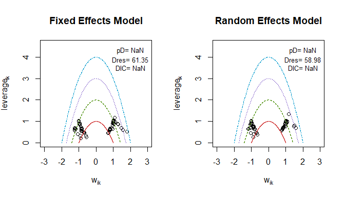

```r
par(mfrow = c(1,2))
nma.fit(fixed_effects_results, main = "Fixed Effects Model" )
nma.fit(random_effects_results, main= "Random Effects Model")
```

## Results

### Regression plot

We can see the effect of the covariate on the log odds ratio on the following plot

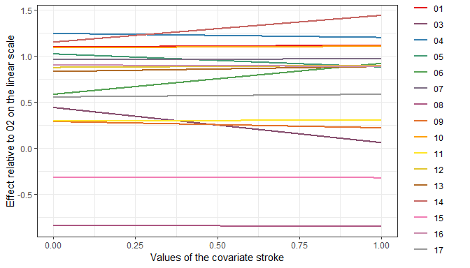

```r
nma.regplot(random_effects_results)
```

The lines are not parallel because we specified EXCHANGEABLE priors on the regression coefficients.

Let’s looks at the relative treatment differences and ranking of treaments when the proportion of patients with a prior stroke is equal to 0.1.

### Sucra Plot

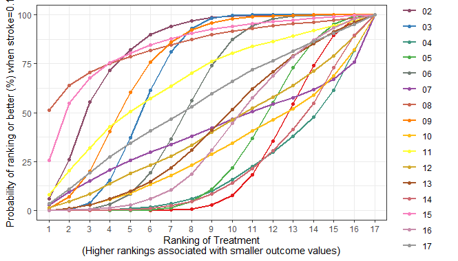

```r
sucra.out <- nma.rank(random_effects_results, largerbetter=FALSE, cov.value=0.1, sucra.palette= "Set1")
sucra.out$sucraplot
```

### League Plot

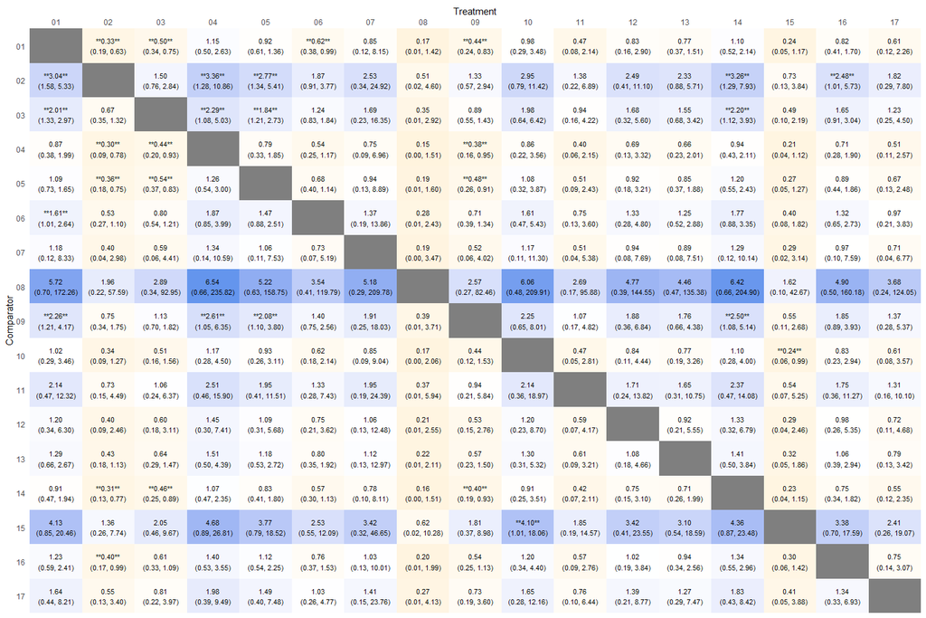

```r
league.out <- nma.league(random_effects_results,
                             central.tdcy = "median",
                             order = as.vector(t(dataprep$treatments)),
                             cov.value=0.1,
                             log.scale = FALSE)
league.out$heatplot
```

### Forest Plot

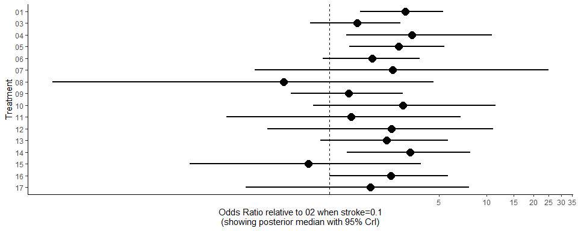

```r
nma.forest(random_effects_results,
           comparator="02",
           central.tdcy = "median",
           cov.value=0.1,
           x.trans="log")
```

# References

Lunn, David, Chris Jackson, Nicky Best, David Spiegelhalter, and Andrew Thomas. 2012. *The Bugs Book: A Practical Introduction to Bayesian Analysis*. Chapman; Hall/CRC.

Plummer, Martyn. 2017. *JAGS Version 4.3.0 User Manual*. http://people.stat.sc.edu/hansont/stat740/jags_user_manual.pdf.